# **R Code sample part 4**

Ivan Baksic

## 3) Random Forest regression and result interpretation

In this part I performed Random Forest regression for a subset of biosamples as an example and displayed result plots for all biosample models. I compared Rsquared Values of different biosample models and correctly determined melanoma cell-of-origin.

Packages used

```r
library(dplyr)
library(tidyr)
library(ggplot2)
library(caret)
library(ranger)
library(forcats)
```

I loaded data frame created in part 3 that contains window counts for chromatin marks and melanoma SNP mutations for each biosample

```r
SKCA_BR_full_WGS_SNP_table_no_out <- readRDS(url("https://github.com/Baksic-Ivan/R_code_sample-Cancer_Cell-of-Origin_Determination/raw/main/SKCA_BR_full_WGS_SNP_table_no_out.RDS"))
head(SKCA_BR_full_WGS_SNP_table_no_out$`Adipose Nuclei`)
```

```
##   H3K27ac H3K9me3 H3K4me3 H3K4me1 H3K27me3 H3K36me3 H3K9ac mutation
## 1     333     272     449     610      562      493    601    12801
## 2     125     404     277     346      851      118    369    12333
## 3      58     511     180     226      772      155    234     5516
## 4      11     603     145      99      730       26    116     4052
## 5     176     241     249     457      520      435    428     7222
## 6     115     344     187     308      597      148    315     4172
```

### Model building

I performed 10-fold cross validation Random Forest regression on all biosamples with chromatin mark counts as predictor variables and melanoma SNP mutation count as response variable.  
As an example I created Random Forest regression models on the first two biosamples:

```r
set.seed(52)
my_analysis <- function (input) {
  sapply(input, function (x) {
    control <- trainControl(method="cv", number=10,returnResamp="final", savePredictions = "final")
    result <- train(mutation ~ .,
                 data = x,
                 method = "ranger",
                 tuneLength = 10,
                 trControl = control,
                 num.trees = 100,
                 importance = "permutation",
                 metric = "Rsquared")
    return(list(max(result$results$Rsquared), result$pred, result$resample))
  }, USE.NAMES = T)
}
SKCA_BR_full_WGS_SNP_table_no_out_2model <- my_analysis(SKCA_BR_full_WGS_SNP_table_no_out[1:2])
SKCA_BR_full_WGS_SNP_table_no_out_2model
```

```
##       Lung Fibroblast 4 Adipose Derived MSC Cultured Cells
## [1,] 0.06487175         0.06772302
## [2,] data.frame,7       data.frame,7
## [3,] data.frame,4       data.frame,4
```

For each biosample there are several results.  
First row represents model Rsquared value:

```r
SKCA_BR_full_WGS_SNP_table_no_out_2model[1, 1] %>%
  unlist(.)
```

```
##  Lung Fibroblast 4
##         0.06487175
```

Second row contains data frame with observed and predicted values

```r
SKCA_BR_full_WGS_SNP_table_no_out_2model[[2, 1]] %>%
  head(.)
```

```
##   mtry  splitrule min.node.size     pred   obs rowIndex Resample
## 1    2 extratrees             5 6834.163 11280      670   Fold05
## 2    2 extratrees             5 6480.567  8422      668   Fold05
## 3    2 extratrees             5 5028.651  4130      704   Fold05
## 4    2 extratrees             5 5254.420  6155      676   Fold05
## 5    2 extratrees             5 7109.619  2395      802   Fold05
## 6    2 extratrees             5 5702.031  3969      763   Fold05
```

Third row contains RMSE and Rsquared values for each CV Fold.

```r
SKCA_BR_full_WGS_SNP_table_no_out_2model[[3, 1]]
```

```
##        RMSE   Rsquared      MAE Resample
## 1  2375.351 0.08748409 1925.446   Fold04
## 2  2563.942 0.02134929 2018.781   Fold09
## 3  2670.138 0.04596298 2097.341   Fold02
## 4  2603.201 0.08410465 2001.792   Fold05
## 5  2925.916 0.01320861 2263.939   Fold03
## 6  2556.947 0.12105275 2073.226   Fold01
## 7  2423.814 0.11048556 1926.868   Fold07
## 8  2724.599 0.09133173 2168.298   Fold10
## 9  2804.676 0.04368041 2117.702   Fold08
## 10 2696.444 0.03005747 2114.769   Fold06
```

### Biosample comparison

I loaded Random Forest regression results for all 104 biosamples.

```r
SKCA_BR_full_WGS_SNP_table_no_out_104model <- readRDS(url("https://github.com/Baksic-Ivan/R_code_sample-Cancer_Cell-of-Origin_Determination/raw/main/SKCA_BR_full_WGS_SNP_table_no_out_104model.RDS"))
```

I compared Rsquared values between all 104 biosamples.

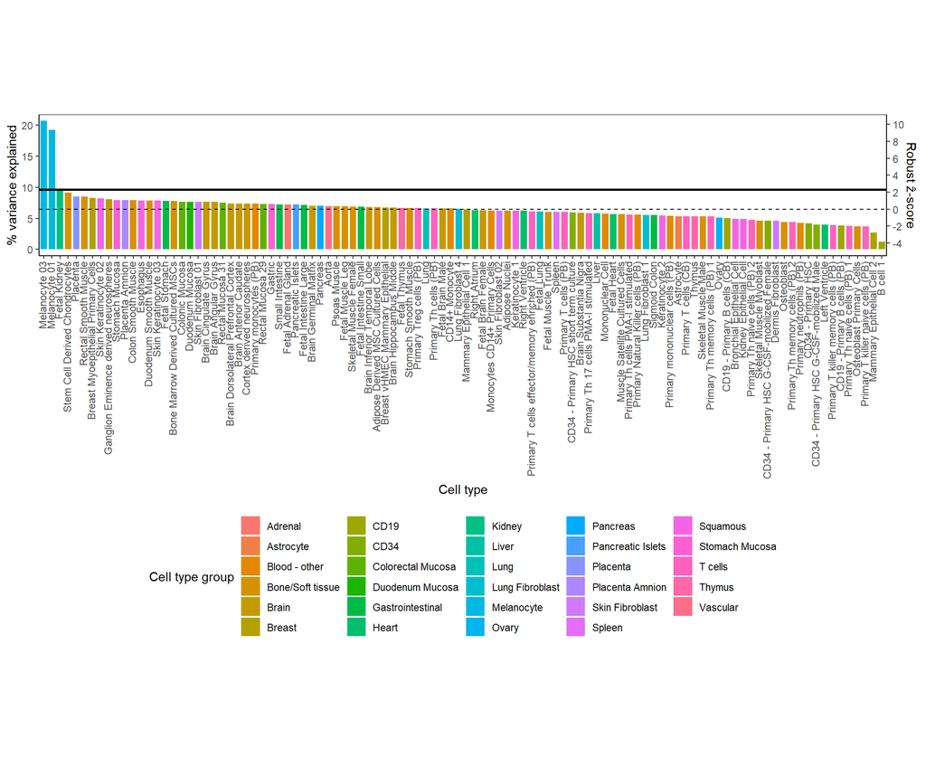

```r
plot_biosamples_score <- function (Rsquared_result) {

  # extract data frame of R2 results for every biosample
  Rsquared_result_table <- Rsquared_result[1, ] %>% unlist(.) %>%
    data.frame(Rsquared = ., biosample = names(.)) %>%
    mutate(., Rsquared = Rsquared*100) %>%
    # arrange it in descending order
    arrange(., desc(Rsquared))

  my_samples <- read.csv("https://raw.githubusercontent.com/Baksic-Ivan/R_code_sample-Cancer_Cell-of-Origin_Determination/main/biomarker_list.csv")

  #add group names to result data frame from biomarker data frame based on biosample column
  Rsquared_result_gg <- my_samples %>% mutate(., biosample = Final.name) %>%
    left_join(Rsquared_result_table, ., by = "biosample")

  # get the position of the second best group of biosamples needed for the full horizontal line
  second_group <- filter(Rsquared_result_gg, Final.group != Final.group[1])
  second_group_pos <- nrow(Rsquared_result_gg) - nrow(second_group) + 1

  plot <- Rsquared_result_gg %>%
    # map biosamples to descending order of Rsquared column
    mutate(biosample = forcats::fct_reorder(biosample, dplyr::desc(Rsquared))) %>%

    #CREATE PLOT
    ggplot(aes(x = biosample, y = Rsquared, fill = Final.group)) +

    # create bar chart
    geom_col(width = 0.8) +

    #adjust themes and axis labels
    theme_classic() +
    theme(axis.text.x = element_text(angle = 90, vjust = 0.3, hjust = 1, size = 9), aspect.ratio = 1/6,
          panel.background = element_rect(colour = "black"),
          legend.position = "bottom") +

    # add horizontal lines at median and second best biosample group
    geom_hline(aes(yintercept = median(Rsquared)), linetype = 2) +
    geom_hline(aes(yintercept = sort(Rsquared, decreasing = T)[second_group_pos]), size = 1) +

    # paint the bars by the biosample group
    guides(fill = guide_legend(title = "Cell type group")) +

    # add second y axis
    scale_y_continuous(name = "% variance explained",
                       sec.axis = sec_axis(~((. - median(Rsquared_result_table$Rsquared)))/mad(Rsquared_result_table$Rsquared),
                                           name = "Robust ẑ-score",
                                           breaks = c (-4, -2, 0, 2, 4, 6, 8, 10))) +
    theme(axis.title.y = element_text(size = rel(1))) +
    labs(x = "Cell type")

  return(plot)
}

plot_biosamples_score(SKCA_BR_full_WGS_SNP_table_no_out_104model)
```

Plot description:  
Solid horizontal line describes variance explained reported by the next-best cell type model that belong to the different cell type group. Dotted horizontal line indicates median variance explained value of all the cell type models. Right-hand (secondary) y-axis shows robust ẑ-score. Bars are colored by histological group.

From this result I can observe that biosamples Melanocyte 03 and Melanocyte 01 have considerably higher Rsquared value than the rest of the biosample models. In order to prove this I performed WMW pair test between neighbouring biosamples based on their fold Rsquared results.

```r
compare_biosamples <- function (input) {

  input_result_table <- input[1, ] %>% unlist(.) %>%
    data.frame(Rsquared = ., biosample = names(.)) %>%
    # arrange it in descending order
    arrange(., desc(Rsquared))


  biosamples_ordered <- input_result_table$biosample

  result <- sapply(1:(length(biosamples_ordered) - 1), function(i) {

    # get Rsquared for each fold for certain biosample
    t1 <- input[[3, biosamples_ordered[i]]] %>%
      arrange(., Resample) %>% .$Rsquared

    # get Rsquared for each fold for neighbour biosample
    t2 <- input[[3, biosamples_ordered[i + 1]]] %>%
      arrange(., Resample) %>% .$Rsquared

    wilcox_result <- wilcox.test(t1, t2, paired = T)
    return(list(biosamples_ordered[i], biosamples_ordered[i + 1], wilcox_result$p.value))
  })
  return(result)
}

WMW_test_biosamples <- compare_biosamples(SKCA_BR_full_WGS_SNP_table_no_out_104model)

WMW_test_biosamples[,1:5]
```

```
##      [,1]            [,2]            [,3]
## [1,] "Melanocyte 03" "Melanocyte 01" "Fetal Kidney"
## [2,] "Melanocyte 01" "Fetal Kidney"  "Stem Cell Derived Chondrocytes"
## [3,] 0.5566406       0.001953125     0.7695312
##      [,4]                             [,5]
## [1,] "Stem Cell Derived Chondrocytes" "Placenta"
## [2,] "Placenta"                       "Rectal Smooth Muscle"
## [3,] 0.4316406                        1
```

First two rows represent biosample neighbours and the third row represents WNW paired test p-value.

Next, I checked which of the pairs has statistically significant different Rsquared value.

```r
WMW_test_biosamples[,WMW_test_biosamples[3,] %>% unlist(.) <= 0.03]
```

```
## [[1]]
## [1] "Melanocyte 01"
##
## [[2]]
## [1] "Fetal Kidney"
##
## [[3]]
## [1] 0.001953125
```

The only statistically significant different Rsquared value is between biosample Melanocyte 01 Fetal Kidney.

Finally, I concluded that the cell type that fits the model with the highest prediction accuracy (Melanocyte) and significantly differs from the next-best histologically unrelated cell type (Fetal Kidney) is the correct cell-of-origin.